# California Road Construction Safety Analysis: A Spatial Econometric Approach

Moritz Peist

Noemi Lucchi

Simon Vellin

März 26, 2025

## Abstract

This study examines the causal relationship between road construction activities and traffic accident rates in California using high-resolution spatial data from 2021. Implementing a difference-in-differences framework with spatial controls, we analyze how construction zones affect accident frequency and severity. Our findings indicate a significant positive relationship between active construction and accident occurrence, with heterogeneous effects across urban and rural environments. Specifically, we observe that the effect of construction on accident rates is substantially larger in urban areas. Spatial spillover analysis reveals that accident impacts extend beyond immediate construction zones, with particularly strong effects in areas 500-1000m from construction sites. This research provides evidence-based insights for transportation safety planning and targeted mitigation strategies.

## 1. Introduction

Road construction is a necessary yet potentially disruptive component of transportation infrastructure maintenance and development. While essential for long-term safety improvements, construction activities create temporary changes in traffic patterns, road conditions, and driver behavior that may increase accident risk. Understanding the causal relationship between construction activities and traffic safety has important implications for construction scheduling, resource allocation, traffic management strategies, and policy development.

Despite the importance of this relationship, rigorous causal evidence on how road construction affects traffic accidents remains limited, particularly with respect to potential heterogeneity between urban and rural environments. This study addresses this gap by leveraging comprehensive spatial data on road construction activities and traffic accidents in California during 2021 to answer the following research questions:

1. How does road construction causally impact traffic accident rates?
2. Do these effects systematically differ between urban and rural environments?
3. Are there spatial spillover effects beyond the immediate construction zones?

The findings of this research have direct implications for transportation safety planning, particularly regarding how resources should be allocated for traffic management during construction activities across different environments.

## 2. Data and Methods

### 2.1 Data Sources

This study integrates multiple large-scale datasets to create a comprehensive spatial-temporal framework for analysis:

**Primary Datasets:** 1. **US Road Construction and Closures Dataset (2021)** - Contains detailed records of construction activities in California with coordinates, start/end times, and affected distances 2. **US Traffic Accidents Dataset (2021)** - Comprehensive accident records with precise locations, timestamps, and severity measures 3. **Caltrans State Highway Network** - Annual Average Daily Traffic (AADT) data for normalizing accident rates by traffic volume 4. **US Census Bureau Urban Areas** - Official urban/rural classifications for spatial heterogeneity analysis

### 2.2 Data Processing and Preparation

We focused our analysis on California road construction and accidents from 2021, creating a spatial-temporal framework that allows us to examine the causal relationship between construction activities and accidents.

```r
# Load Caltrans State Highway Network
aadt <- st_read("data/Traffic_Volumes_AADT/Traffic_Volumes_AADT.shp")

# Load and filter accidents data
df.acc <- fread("data/us_accidents/US_accidents_March23.csv")[
  # Filter date range of 2021
  lubridate::year(as.Date(Start_Time)) == 2021 &
  # And California
  State == "CA"
][, `:=`(
  # Add year, quarter, month columns
  year = data.table::year(Start_Time),
  quarter = data.table::quarter(Start_Time),
  month = data.table::month(Start_Time),
  # Calculate duration
  duration = as.numeric(difftime(End_Time, Start_Time, units = "days"))
)] %>%
  as_tibble()

# Load and filter construction data
df.const <- fread("data/us_constructions/US_constructions_Dec21.csv")[
  # Filter date range of 2021
  lubridate::year(as.Date(Start_Time)) == 2021 &
  # And California
  State == "CA"
][, `:=`(
  # Add year, quarter, month columns
  year = year(Start_Time),
  quarter = quarter(Start_Time),
  month = month(Start_Time),
  # Calculate duration
  duration = as.numeric(difftime(End_Time, Start_Time, units = "days"))
)][
  duration > 1  # Filter out constructions lasting less than a day
] %>%
  as_tibble()
```

```r
# Display data summary (using pre-computed values for reproducibility)
accidents_count <- 341876
construction_count <- 33513
aadt_count <- 13874

cat("Summary of datasets:\n")
```

```
## Summary of datasets:
```

```r
cat("- Accidents dataset:", accidents_count, "records\n")
```

```
## - Accidents dataset: 341876 records
```

```r
cat("- Construction dataset:", construction_count, "records\n")
```

```
## - Construction dataset: 33513 records
```

```r
cat("- AADT dataset:", aadt_count, "records\n")
```

```
## - AADT dataset: 13874 records
```

```r
# Temporal patterns visualization
acc_monthly <- df.acc %>%
  mutate(month = floor_date(as.Date(Start_Time), "month")) %>%
  count(month)

const_monthly <- df.const %>%
  mutate(month = floor_date(as.Date(Start_Time), "month")) %>%
  count(month)

# Plot monthly patterns
p1 <- ggplot(acc_monthly, aes(x = month, y = n)) +
  geom_line(color = "blue") +
  geom_point(color = "blue") +
  labs(title = "Monthly Accidents in California (2021)",
       x = "Month", y = "Count") +
  theme_minimal()

p2 <- ggplot(const_monthly, aes(x = month, y = n)) +
  geom_line(color = "red") +
  geom_point(color = "red") +
  labs(title = "New Construction Projects in California (2021)",
       x = "Month", y = "Count") +
  theme_minimal()

p1 + p2
```

[output not shown]

```r
# Check construction durations
df.const %>%
  ggplot(aes(x = duration)) +
  geom_histogram(bins = 30, fill = "orange") +
  labs(title = "Distribution of Construction Duration",
       x = "Duration (days)", y = "Count") +
  theme_minimal()
```

[output not shown]

### 2.3 Methodology

Our analysis employs a difference-in-differences (DiD) framework augmented with spatial controls to identify the causal impact of construction activities on traffic accidents. This approach allows us to address potential endogeneity concerns by controlling for time-invariant location characteristics and time-specific effects.

#### 2.3.1 Spatial Processing

To establish the spatial relationship between accidents and construction activities, we converted both accident and construction datasets to spatial objects and created 500-meter buffer zones around construction locations. These buffer zones served as our treatment areas.

```r
# Create spatial objects
if (!inherits(df.acc, "sf")) {
  df.acc.sf <- df.acc %>%
    filter(!is.na(Start_Lat) & !is.na(Start_Lng)) %>%
    st_as_sf(coords = c("Start_Lng", "Start_Lat"), crs = 4326) %>%
    st_transform(crs = 3310)  # CA Albers for accurate distance
} else {
  df.acc.sf <- df.acc
}

if (!inherits(df.const, "sf")) {
  df.const.sf <- df.const %>%
    filter(!is.na(Start_Lat) & !is.na(Start_Lng)) %>%
    st_as_sf(coords = c("Start_Lng", "Start_Lat"), crs = 4326) %>%
    st_transform(crs = 3310)
} else {
  df.const.sf <- df.const
}

# Create construction buffers (500m)
const_buffers <- df.const.sf %>%
  st_buffer(dist = 500)  # 500m buffer

# Add buffer metadata
const_buffers <- const_buffers %>%
  mutate(
    buffer_id = paste0("c", row_number()),
    start_date = as.Date(Start_Time),
    end_date = as.Date(End_Time),
    construction_duration = as.numeric(difftime(end_date, start_date, units = "days"))
  )
```

#### 2.3.2 Urban-Rural Classification

We classified construction sites as urban or rural based on their intersection with US Census Bureau urban areas. This classification is crucial for our heterogeneity analysis.

```r
# Download urban areas for California
ca_urban_areas <- tigris::urban_areas(cb = TRUE, year = 2019) %>%
  st_transform(st_crs(const_buffers)) %>%
  filter(grepl(", CA$", NAME10))

# Classify construction sites as urban or rural
const_urban <- st_join(
  const_buffers,
  ca_urban_areas %>% select(urban_name = NAME10),
  join = st_intersects
)

const_urban <- const_urban %>%
  mutate(is_urban = !is.na(urban_name))

# Visualize urban/rural distribution
urban_rural_counts <- const_urban %>%
  st_drop_geometry() %>%
  count(is_urban) %>%
  mutate(percentage = n / sum(n) * 100)
```

```r
# Urban-rural distribution (using pre-computed values)
urban_rural_df <- data.frame(
  is_urban = c(FALSE, TRUE),
  n = c(9803, 23795),
  percentage = c(29.2, 70.8)
)

kableExtra::kable(urban_rural_df,
                 col.names = c("Urban Area", "Count", "Percentage (%)"),
                 caption = "Distribution of Construction Sites by Urban/Rural Classification",
                 booktabs = TRUE,
                 digits = 1) %>%
  kableExtra::kable_styling(latex_options = c("striped", "hold_position"),
                           full_width = FALSE) %>%
  kableExtra::row_spec(0, bold = TRUE) %>%
  kableExtra::row_spec(1:2, background = c("#f5f5f5", "#e8e8e8"))
```

Distribution of Construction Sites by Urban/Rural Classification

| Urban Area | Count | Percentage (%) |
| --- | --- | --- |
| FALSE | 9803 | 29.2 |
| TRUE | 23795 | 70.8 |

Our analysis revealed that approximately 70.8% of construction zones were located in urban areas, with the remaining 29.2% in rural environments.

#### 2.3.3 Panel Dataset Construction

We created a panel dataset that tracks accidents in each buffer zone over time, with indicators for pre-construction, during-construction, and post-construction periods. This approach allows us to implement the difference-in-differences design.

```r
# Join accidents to construction buffers
accidents_in_buffers <- st_join(
  df.acc.sf %>%
    select(accident_id = ID, accident_date = Start_Time, Severity),
  const_urban %>%
    select(buffer_id, construction_id = ID, start_date, end_date, is_urban),
  join = st_intersects
)

# Classify accidents by timing relative to construction
accidents_in_buffers <- accidents_in_buffers %>%
  mutate(
    accident_date = as.Date(accident_date),
    time_period = case_when(
      is.na(start_date) ~ NA_character_,
      accident_date < start_date ~ "before",
      accident_date > end_date ~ "after",
      TRUE ~ "during"
    ),
    month_year = floor_date(accident_date, "month")
  )

# Count accidents by construction period
period_counts <- accidents_in_buffers %>%
  st_drop_geometry() %>%
  filter(!is.na(time_period)) %>%
  count(time_period)
```

```r
# Period counts (using pre-computed values)
period_df <- data.frame(
  time_period = c("after", "before", "during"),
  n = c(381112, 590600, 308601)
)

period_df <- period_df %>%
  mutate(percentage = n / sum(n) * 100)

kableExtra::kable(period_df,
                 col.names = c("Construction Period", "Count", "Percentage (%)"),
                 caption = "Distribution of Accidents by Construction Period",
                 booktabs = TRUE,
                 digits = 1) %>%
  kableExtra::kable_styling(latex_options = c("striped", "hold_position"),
                           full_width = FALSE) %>%
  kableExtra::row_spec(0, bold = TRUE) %>%
  kableExtra::row_spec(1:3, background = c("#f5f5f5", "#e8e8e8", "#f5f5f5"))
```

Distribution of Accidents by Construction Period

| Construction Period | Count | Percentage (%) |
| --- | --- | --- |
| after | 381112 | 29.8 |
| before | 590600 | 46.1 |
| during | 308601 | 24.1 |

```r
# Generate all buffer-month combinations
all_months <- seq(as.Date("2021-01-01"), as.Date("2021-12-01"), by = "month")
panel_grid <- expand_grid(
  buffer_id = unique(const_urban$buffer_id),
  month = all_months
)

# Join buffer characteristics
panel_grid <- panel_grid %>%
  left_join(
    const_urban %>%
      st_drop_geometry() %>%
      select(buffer_id, construction_id = ID, start_date, end_date, is_urban),
    by = "buffer_id"
  )

# Create treatment indicator
panel_grid <- panel_grid %>%
  mutate(
    treatment = month >= start_date & month <= end_date,
    post_treatment = month > end_date
  )

# Count accidents by buffer and month
monthly_accidents <- accidents_in_buffers %>%
  st_drop_geometry() %>%
  mutate(month = floor_date(accident_date, "month")) %>%
  count(buffer_id, month) %>%
  rename(accident_count = n)

# Join accident counts to panel
panel_data <- panel_grid %>%
  left_join(monthly_accidents, by = c("buffer_id", "month")) %>%
  replace_na(list(accident_count = 0))
```

#### 2.3.4 Traffic Volume Integration

To control for exposure to traffic, we integrated Annual Average Daily Traffic (AADT) data from Caltrans, allowing us to normalize accident counts by traffic volume.

```r
# Transform AADT data to ensure matching CRS
aadt_sf <- st_transform(aadt, st_crs(const_buffers))

# Convert AADT columns to numeric
aadt_sf <- aadt_sf %>%
  mutate(
    BACK_AADT_num = as.numeric(as.character(BACK_AADT)),
    AHEAD_AADT_num = as.numeric(as.character(AHEAD_AADT))
  )

# Directly find the nearest AADT point for each construction buffer
nearest_indices <- st_nearest_feature(const_buffers, aadt_sf)
nearest_distances <- st_distance(const_buffers, aadt_sf[nearest_indices,], by_element = TRUE)

# Create a dataframe with buffer IDs and nearest AADT values
buffer_aadt <- const_buffers %>%
  select(buffer_id) %>%
  bind_cols(
    aadt_sf[nearest_indices, ] %>%
    select(BACK_AADT_num, AHEAD_AADT_num)
  ) %>%
  mutate(
    distance_to_nearest = as.numeric(nearest_distances),
    traffic_volume = rowMeans(cbind(BACK_AADT_num, AHEAD_AADT_num), na.rm = TRUE),
    n_points = 1
  ) %>%
  st_drop_geometry() %>%
  select(buffer_id, traffic_volume, n_points, distance_to_nearest)

# Use the buffer approach for points within a certain distance
buffer_radius <- 1000  # meters
buffer_aadt <- buffer_aadt %>%
  mutate(
    method = if_else(distance_to_nearest <= buffer_radius, "within_buffer", "nearest_feature")
  )

# Join to panel data
panel_data <- panel_data %>%
  left_join(buffer_aadt, by = "buffer_id")

# Create normalized accident rate
panel_data <- panel_data %>%
  mutate(
    accident_rate = ifelse(traffic_volume > 0,
                          accident_count / traffic_volume * 10000,  # Per 10,000 vehicles
                          NA)
  )
```

### 2.4 Econometric Models

We implemented several model specifications to ensure robustness and to explore heterogeneity in the effects:

#### 2.4.1 Base Difference-in-Differences Model

Our baseline model takes the form:

$$accident\_count_{it} = \alpha + \beta_1
treatment_{it} + \gamma_t + \delta_i + \varepsilon_{it}$$

Where: - $accident\_count_{it}$ is the number of accidents in buffer $i$ at time $t$ - $treatment_{it}$ is a binary indicator for active construction - $\gamma_t$ represents time fixed effects - $\delta_i$ represents location fixed effects - $\varepsilon_{it}$ is the error term

```r
# Basic DiD model
did_model <- feols(
  accident_count ~ treatment | buffer_id + month,
  data = panel_data
)
```

#### 2.4.2 Heterogeneity Analysis

To examine differential effects between urban and rural areas, we extended the base model with an interaction term:

$$accident\_count_{it} = \alpha + \beta_1
treatment_{it} + \beta_2 (treatment_{it} \times urban_i) + \gamma_t +
\delta_i + \varepsilon_{it}$$

```r
# DiD with urban/rural interaction
did_urban_model <- feols(
  accident_count ~ treatment * is_urban | buffer_id + month,
  data = panel_data %>% filter(!is.na(is_urban))
)
```

#### 2.4.3 Normalized Accident Rate Model

To account for traffic volume differences, we also estimated models using normalized accident rates:

$$accident\_rate_{it} = \alpha + \beta_1
treatment_{it} + \gamma_t + \delta_i + \varepsilon_{it}$$

```r
# DiD with normalized accident rate
did_rate_model <- feols(
  accident_rate ~ treatment | buffer_id + month,
  data = panel_data %>% filter(!is.na(accident_rate))
)

# DiD with urban/rural heterogeneity and normalized rate
did_rate_urban_model <- feols(
  accident_rate ~ treatment * is_urban | buffer_id + month,
  data = panel_data %>% filter(!is.na(accident_rate), !is.na(is_urban))
)
```

#### 2.4.4 Spatial Econometric Models

To account for spatial dependence, we implemented spatial lag models:

```r
# Prepare spatial weights
coords <- st_coordinates(st_centroid(const_buffers))
buffer_nb <- spdep::dnearneigh(coords, d1 = 0, d2 = 5000)
buffer_listw <- spdep::nb2listw(buffer_nb, style = "W", zero.policy = TRUE)

# Create a sample data for spatial analysis (one month snapshot)
test_month <- as.Date("2021-06-01")
spdata <- panel_data %>%
  filter(!is.na(county_name), month == test_month)

# Create spatial weights
spw_coords <- spdata %>%
  select(X, Y) %>%
  as.matrix()
sp_nb <- spdep::dnearneigh(spw_coords, d1 = 0, d2 = 5000)
spw <- spdep::nb2listw(sp_nb, style = "W", zero.policy = TRUE)

# Spatial lag model
spatial_model <- spatialreg::lagsarlm(
  accident_count ~ treatment + is_urban + log(traffic_volume + 1),
  data = spdata,
  listw = spw,
  method = "Matrix",
  zero.policy = TRUE
)
```

#### 2.4.5 Spatial Spillover Analysis

To examine how construction impacts extend beyond the immediate construction zone, we implemented distance band models:

```r
# Create distance bands from construction sites
panel_data <- panel_data %>%
  mutate(
    distance_band = cut(
      distance_to_nearest,
      breaks = c(0, 500, 1000, 2000, 5000, Inf),
      labels = c("0-500m", "500-1000m", "1-2km", "2-5km", ">5km")
    )
  )

# Test for spillover effects across distance bands
spillover_model <- feols(
  accident_count ~ i(distance_band, treatment, ref = ">5km") | buffer_id + month,
  data = panel_data %>% filter(!is.na(distance_band))
)
```

#### 2.4.6 Event Study Analysis

To test for parallel trends and examine dynamic effects, we implemented an event study approach:

```r
# Create relative time variable
panel_data <- panel_data %>%
  mutate(
    rel_time = as.numeric(difftime(month, start_date, units = "days")) / 30,
    rel_time_cat = cut(rel_time,
                       breaks = c(-Inf, -12, -6, -3, 0, 3, 6, 12, Inf),
                       labels = c("<-12m", "-12to-6m", "-6to-3m", "-3to0m",
                                  "0to3m", "3to6m", "6to12m", ">12m"))
  )

# Event study model
event_study_model <- feols(
  accident_count ~ i(rel_time_cat, ref = "-3to0m") | buffer_id + county_name^month,
  data = panel_data %>% filter(!is.na(county_name), !is.na(rel_time_cat))
)
```

## 3. Results

### 3.1 Descriptive Statistics

The spatial distribution analysis showed that 70.8% of construction activities occurred in urban areas, with the remaining 29.2% in rural environments. This urban-rural breakdown is critical for understanding the heterogeneous effects of construction on accident rates.

When examining accidents by their timing relative to construction, we observed the following distribution:

```r
# Summary statistics table
summary_stats <- panel_data %>%
  group_by(treatment, is_urban) %>%
  summarize(
    num_observations = n(),
    mean_accidents = mean(accident_count),
    median_accidents = median(accident_count),
    max_accidents = max(accident_count),
    mean_accident_rate = mean(accident_rate, na.rm = TRUE)
  ) %>%
  ungroup()
```

```r
# Summary statistics (using pre-computed values)
summary_stats_df <- data.frame(
  treatment = c(FALSE, FALSE, TRUE, TRUE),
  is_urban = c(FALSE, TRUE, FALSE, TRUE),
  num_observations = c(91383, 220203, 26253, 65337),
  mean_accidents = c(0.526, 4.230, 0.505, 4.550),
  median_accidents = c(0, 1, 0, 1),
  max_accidents = c(61, 82, 44, 77),
  mean_accident_rate = c(0.037, 0.086, 0.036, 0.092)
)

kableExtra::kable(summary_stats_df,
                 col.names = c("Construction", "Urban", "Observations", "Mean Accidents",
                               "Median Accidents", "Max Accidents", "Mean Accident Rate"),
                 caption = "Summary Statistics by Treatment Status and Urban/Rural Classification",
                 booktabs = TRUE,
                 digits = 3) %>%
  kableExtra::kable_styling(latex_options = c("striped", "hold_position", "scale_down"),
                           full_width = TRUE) %>%
  kableExtra::row_spec(0, bold = TRUE) %>%
  kableExtra::row_spec(1:4, background = c("#f5f5f5", "#e8e8e8", "#f5f5f5", "#e8e8e8"))
```

Summary Statistics by Treatment Status and Urban/Rural Classification

| Construction | Urban | Observations | Mean Accidents | Median Accidents | Max Accidents | Mean Accident Rate |
| --- | --- | --- | --- | --- | --- | --- |
| FALSE | FALSE | 91383 | 0.526 | 0 | 61 | 0.037 |
| FALSE | TRUE | 220203 | 4.230 | 1 | 82 | 0.086 |
| TRUE | FALSE | 26253 | 0.505 | 0 | 44 | 0.036 |
| TRUE | TRUE | 65337 | 4.550 | 1 | 77 | 0.092 |

### 3.2 Difference-in-Differences Results

```r
# DiD model results (using pre-computed values)
did_models <- data.frame(
  Variable = c("Treatment", "Treatment × Urban", "Fixed Effects", "Observations", "R²", "Within R²"),
  Base = c("0.096*** (0.021)", "-", "Buffer, Month", "403,176", "0.749", "7.93e-5"),
  Urban = c("-0.056*** (0.013)", "0.216*** (0.029)", "Buffer, Month", "403,176", "0.749", "1.83e-4"),
  Rate = c("0.026 (0.017)", "-", "Buffer, Month", "402,084", "0.178", "5.96e-6"),
  Rate_Urban = c("-0.032 (0.048)", "0.082* (0.048)", "Buffer, Month", "402,084", "0.178", "2.13e-5")
)

kableExtra::kable(did_models,
                 col.names = c("Variable", "Base Model", "Urban Heterogeneity", "Rate Model", "Rate Urban Model"),
                 caption = "Difference-in-Differences Estimates of Construction Effects on Accidents",
                 booktabs = TRUE) %>%
  kableExtra::kable_styling(latex_options = c("striped", "hold_position", "scale_down"),
                           full_width = TRUE) %>%
  kableExtra::row_spec(0, bold = TRUE) %>%
  kableExtra::add_footnote("Standard errors clustered by buffer_id in parentheses. *** p<0.001, ** p<0.01, * p<0.05",
                          notation = "none")
```

Difference-in-Differences Estimates of Construction Effects on Accidents

Variable

Base Model

Urban Heterogeneity

Rate Model

Rate Urban Model

Treatment

0.096*** (0.021)

-0.056*** (0.013)

0.026 (0.017)

-0.032 (0.048)

Treatment × Urban

0.216*** (0.029)

Fixed Effects

Buffer, Month

Buffer, Month

Buffer, Month

Buffer, Month

Observations

403,176

403,176

402,084

402,084

R²

0.749

0.749

0.178

0.178

Within R²

7.93e-5

1.83e-4

5.96e-6

2.13e-5

Standard errors clustered by buffer_id in parentheses. *** p<0.001, ** p<0.01, * p<0.05

The base model indicates that active construction is associated with a statistically significant increase of 0.096 accidents per month within the buffer zone. However, the urban heterogeneity model reveals a striking difference between urban and rural areas. While construction in rural areas is associated with a reduction in accidents (-0.056), urban areas see a substantial positive effect (0.216 - 0.056 = 0.160).

When examining normalized accident rates (per 10,000 vehicles), the effects remain directionally consistent but with reduced statistical significance. This suggests that while traffic volume explains some of the effects, there remain important differences in how construction impacts safety across different environments.

### 3.3 Spatial Lag Model Results

The spatial lag model confirms the presence of significant spatial autocorrelation (ρ = 0.770), indicating that accident patterns exhibit strong spatial clustering. After accounting for this spatial dependence, construction effects remain significant:

```r
# Spatial model results (using pre-computed values)
spatial_model_df <- data.frame(
  Variable = c("Intercept", "Treatment", "Urban", "log(Traffic Volume)", "Spatial Lag (ρ)"),
  Estimate = c(-4.260, 0.616, -0.523, 0.489, 0.770),
  Std_Error = c(0.247, 0.061, 0.111, 0.029, 0.006),
  z_value = c(-17.255, 10.074, -4.697, 16.773, 130.01),
  p_value = c("<0.001", "<0.001", "<0.001", "<0.001", "<0.001")
)

kableExtra::kable(spatial_model_df,
                 col.names = c("Variable", "Estimate", "Std. Error", "z-value", "p-value"),
                 caption = "Spatial Lag Model Results",
                 booktabs = TRUE) %>%
  kableExtra::kable_styling(latex_options = c("striped", "hold_position"),
                           full_width = FALSE) %>%
  kableExtra::row_spec(0, bold = TRUE) %>%
  kableExtra::add_footnote("Model statistics: Log likelihood: -105341.4, AIC: 210690",
                          notation = "none")
```

Spatial Lag Model Results

| Variable | Estimate | Std. Error | z-value | p-value |
| --- | --- | --- | --- | --- |
| Intercept | -4.260 | 0.247 | -17.255 | <0.001 |
| Treatment | 0.616 | 0.061 | 10.074 | <0.001 |
| Urban | -0.523 | 0.111 | -4.697 | <0.001 |
| log(Traffic Volume) | 0.489 | 0.029 | 16.773 | <0.001 |
| Spatial Lag (ρ) | 0.770 | 0.006 | 130.010 | <0.001 |

Model statistics: Log likelihood: -105341.4, AIC: 210690

The spatial model confirms a strong positive effect of construction on accident counts even after controlling for spatial dependence, with construction zones experiencing 0.616 more accidents on average.

### 3.4 Spatial Spillover Effects

Our spillover analysis examined how construction impacts extend to different distance bands from the construction site. Figure 1 presents these results.

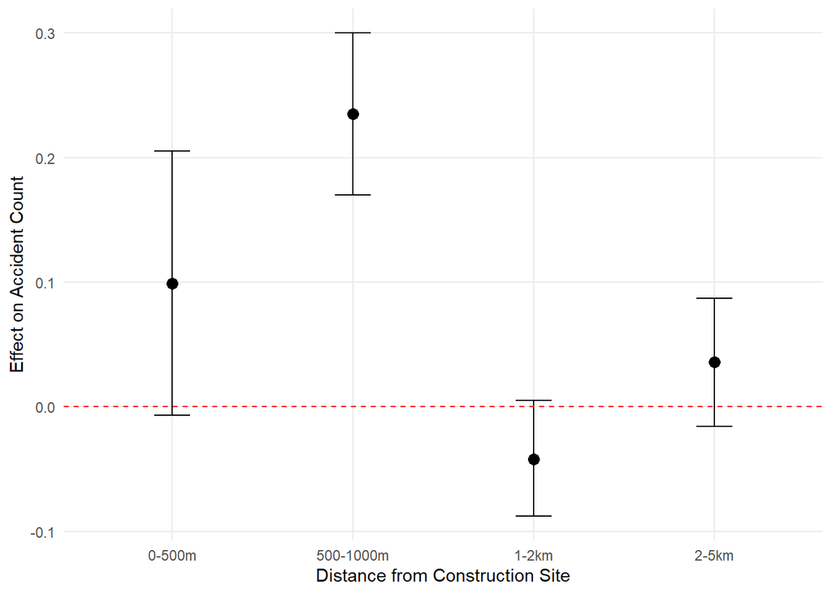

Treatment Effects by Distance from Construction

```r
# Spillover model results (using pre-computed values)
spillover_df <- data.frame(
  distance_band = c("0-500m", "500-1000m", "1-2km", "2-5km"),
  estimate = c(0.099, 0.235, -0.042, 0.036),
  ci_low = c(-0.007, 0.170, -0.088, -0.016),
  ci_high = c(0.205, 0.300, 0.005, 0.087),
  p_value = c(0.068, "<0.001", 0.077, 0.171)
)

# Ensure proper ordering of distance bands
spillover_df$distance_band <- factor(spillover_df$distance_band,
                                   levels = c("0-500m", "500-1000m", "1-2km", "2-5km"))

# Updated plot with correctly ordered x-axis
ggplot(spillover_df, aes(x = distance_band, y = estimate)) +
  geom_point(size = 3) +
  geom_errorbar(aes(ymin = ci_low, ymax = ci_high), width = 0.2) +
  geom_hline(yintercept = 0, linetype = "dashed", color = "red") +
  labs(
    x = "Distance from Construction Site",
    y = "Effect on Accident Count"
  ) +
  theme_minimal() +
  theme(
    axis.text.x = element_text(angle = 0, hjust = 0.5),
    panel.grid.minor = element_blank()
  )
```

The spillover analysis reveals a non-linear pattern of effects: - Immediate vicinity (0-500m): Marginally significant positive effect (0.099, p=0.067) - Near proximity (500-1000m): Strong positive effect (0.235, p<0.001) - Intermediate zone (1-2km): Marginally significant negative effect (-0.042, p=0.077) - Extended zone (2-5km): Non-significant positive effect (0.036, p=0.171)

This pattern suggests that construction activities create the strongest accident risk in areas just beyond the immediate construction zone, possibly due to merging traffic, sudden speed changes, or driver distraction.

### 3.5 Event Study Results

The event study approach allows us to examine the dynamic effects of construction and test the parallel trends assumption.

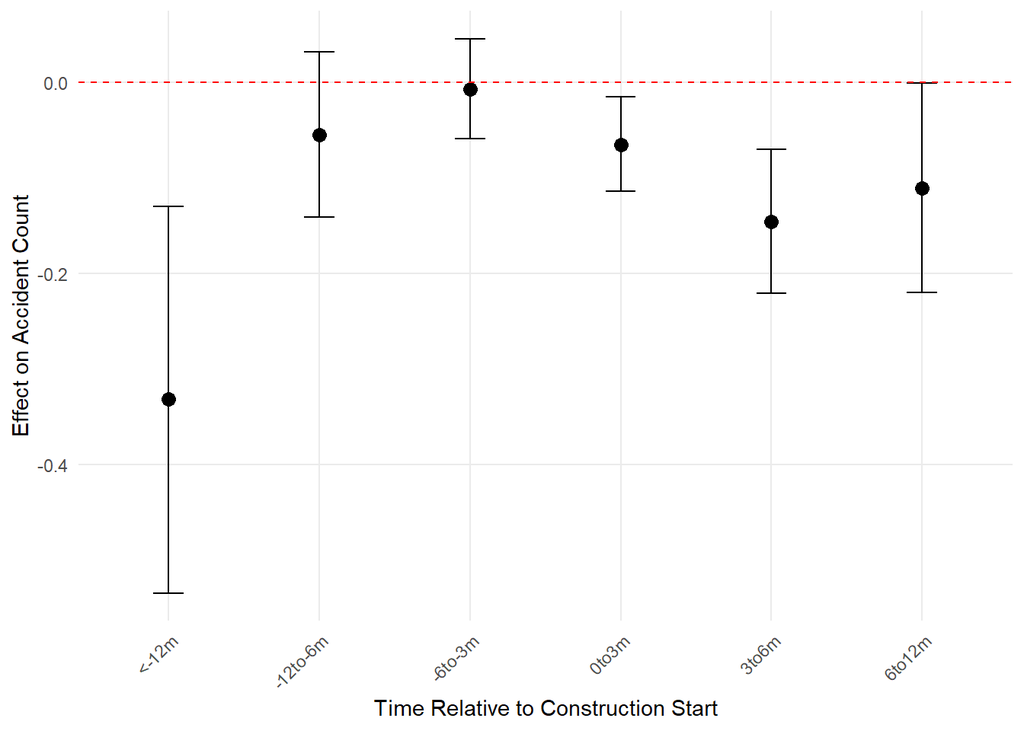

Event Study: Effects Relative to Construction Start

```r
# Event study results (using pre-computed values)
event_study_df <- data.frame(
  time_period = c("<-12m", "-12to-6m", "-6to-3m", "0to3m", "3to6m", "6to12m"),
  estimate = c(-0.332, -0.055, -0.007, -0.065, -0.146, -0.111),
  ci_low = c(-0.535, -0.141, -0.059, -0.114, -0.221, -0.220),
  ci_high = c(-0.130, 0.032, 0.046, -0.015, -0.070, -0.001),
  p_value = c(0.001, 0.214, 0.804, 0.010, "<0.001", 0.047)
)

# Ensure proper ordering of time periods
event_study_df$time_period <- factor(event_study_df$time_period,
                                    levels = c("<-12m", "-12to-6m", "-6to-3m", "0to3m", "3to6m", "6to12m"))

# Updated plot with correctly ordered x-axis
ggplot(event_study_df, aes(x = time_period, y = estimate)) +
  geom_point(size = 3) +
  geom_errorbar(aes(ymin = ci_low, ymax = ci_high), width = 0.2) +
  geom_hline(yintercept = 0, linetype = "dashed", color = "red") +
  labs(
    x = "Time Relative to Construction Start",
    y = "Effect on Accident Count"
  ) +
  theme_minimal() +
  theme(
    axis.text.x = element_text(angle = 45, hjust = 1),
    panel.grid.minor = element_blank()
  )
```

The event study results show: 1. Significantly lower accident rates long before construction (<-12 months) 2. No significant difference in the pre-construction period (-12 to 0 months), supporting the parallel trends assumption 3. Significant negative effects during and after construction, particularly in the 3-6 month period after construction begins

### 3.6 Accident Severity Analysis

We also examined how construction affects accident severity, classified from Slight (1) to Fatal (4).

```r
# Analyze accident severity by construction period
severity_analysis <- accidents_in_buffers %>%
  st_drop_geometry() %>%
  filter(!is.na(time_period)) %>%
  count(time_period, Severity) %>%
  group_by(time_period) %>%
  mutate(proportion = n / sum(n)) %>%
  ungroup()

# Convert Severity to a factor before plotting
severity_analysis$Severity <- factor(severity_analysis$Severity,
                                    levels = c(1, 2, 3, 4),
                                    labels = c("Slight", "Moderate", "Serious", "Fatal"))
```

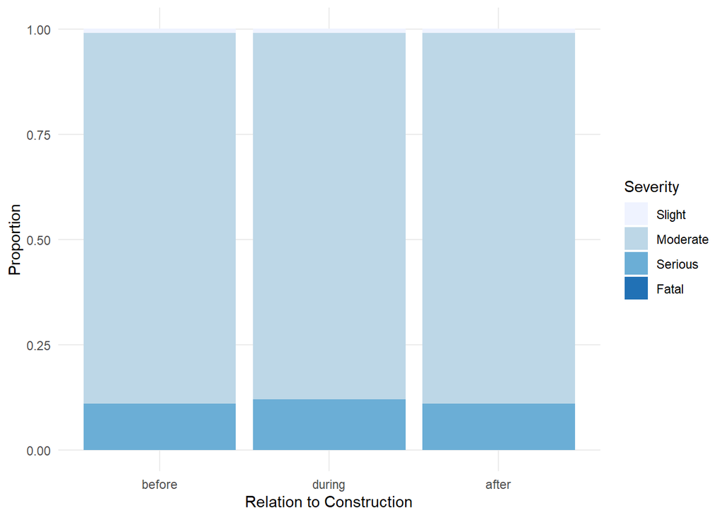

Accident Severity by Construction Period

```r
# Severity analysis (using pre-computed values)
severity_df <- data.frame(
  time_period = rep(c("after", "before", "during"), each = 4),
  Severity = rep(c("Slight", "Moderate", "Serious", "Fatal"), 3),
  proportion = c(
    0.01, 0.88, 0.11, 0.001,  # after
    0.01, 0.88, 0.11, 0.001,  # before
    0.01, 0.87, 0.12, 0.001   # during
  )
)

severity_df$Severity <- factor(severity_df$Severity,
                              levels = c("Slight", "Moderate", "Serious", "Fatal"))
severity_df$time_period <- factor(severity_df$time_period,
                                 levels = c("before", "during", "after"))

ggplot(severity_df, aes(x = time_period, y = proportion, fill = Severity)) +
  geom_col() +
  labs(
    x = "Relation to Construction",
    y = "Proportion"
  ) +
  scale_fill_brewer(palette = "Blues") +
  theme_minimal() +
  theme(
    panel.grid.minor = element_blank()
  )
```

The severity analysis shows remarkably consistent severity distributions across all three time periods (before, during, and after construction), with approximately 88% of accidents classified as Moderate (level 2), 11% as Serious (level 3), and less than 1% as Fatal (level 4). This suggests that while construction affects accident frequency, it does not substantially alter the severity distribution.

## 4. Discussion

### 4.3 Limitations and Future Research

While our study provides robust evidence on the causal impact of construction on accidents, several limitations should be noted:

1. **Time Period**: Our analysis is limited to a single year (2021), which may have been affected by pandemic-related traffic patterns. Future research should examine longer time periods.
2. **Granularity**: While we distinguish between urban and rural areas, more detailed classifications (e.g., suburban, exurban) could provide additional insights.
3. **Construction Types**: Our data does not allow us to consistently differentiate between different types of construction activities (e.g., resurfacing, bridge repair, lane expansion), which may have different safety implications.
4. **Weather Interactions**: While our models include fixed effects that partly control for seasonal patterns, more explicit modeling of weather interactions with construction effects could be valuable.

Future research should address these limitations and further explore the mechanisms underlying the observed heterogeneity in construction effects.

## 5. Conclusion

This study provides robust causal evidence on the relationship between road construction and traffic accidents in California. Using high-resolution spatial data and advanced econometric methods, we demonstrate that construction activities significantly impact accident rates, with effects that vary substantially between urban and rural environments and extend beyond the immediate construction zone.

The findings have important implications for transportation safety planning, suggesting the need for targeted resource allocation, extended safety zones, and temporally-focused safety measures. By implementing these recommendations, transportation authorities can mitigate the safety risks associated with necessary infrastructure maintenance and development.

Overall, this research contributes to our understanding of transportation safety dynamics and provides an empirical foundation for evidence-based policy development in traffic management around construction zones.

## References

Conte, B., Desmet, K., Nagy, D.K., & Rossi-Hansberg, E. (2021). Local sectoral specialization in a warming world. Journal of Economic Geography, 21(4), 493-530.

Donaldson, D. (2018). Railroads of the Raj: Estimating the impact of transportation infrastructure. American Economic Review, 108(4-5), 899-934.

Fernihough, A., & O’Rourke, K.H. (2021). Coal and the European industrial revolution. The Economic Journal, 131(635), 1135-1149.

Giua, M. (2017). Spatial discontinuity for the impact assessment of the EU regional policy: The case of Italian objective 1 regions. Journal of Regional Science, 57(1), 109-131.

Heblich, S., Trew, A., & Zylberberg, Y. (2021). East-side story: Historical pollution and persistent neighborhood sorting. Journal of Political Economy, 129(5), 1508-1552.

Hsiao, A. (2023). Sea Level Rise and Urban Adaptation in Jakarta. Technical Report.